# ST558: Project1

Aniket Walimbe

9/11/2022

## Step 1

```r
sheet2 <- sheet1 %>%
  select(Area_name, STCOU, ends_with("D")) %>%
  rename("area_name" = Area_name)


sheet2
```

```
## # A tibble: 3,198 × 12
##    area_…¹ STCOU EDU01…² EDU01…³ EDU01…⁴ EDU01…⁵ EDU01…⁶ EDU01…⁷ EDU01…⁸ EDU01…⁹
##    <chr>   <chr>   <dbl>   <dbl>   <dbl>   <dbl>   <dbl>   <dbl>   <dbl>   <dbl>
##  1 UNITED… 00000  4.00e7  4.00e7  4.03e7  4.07e7  4.14e7  4.21e7  4.27e7  4.34e7
##  2 ALABAMA 01000  7.34e5  7.28e5  7.30e5  7.28e5  7.26e5  7.26e5  7.28e5  7.31e5
##  3 Autaug… 01001  6.83e3  6.9 e3  6.92e3  6.85e3  7.01e3  7.14e3  7.15e3  7.38e3
##  4 Baldwi… 01003  1.64e4  1.65e4  1.68e4  1.71e4  1.75e4  1.80e4  1.87e4  1.94e4
##  5 Barbou… 01005  5.07e3  5.10e3  5.07e3  5.16e3  5.17e3  5.25e3  5.14e3  5.11e3
##  6 Bibb, … 01007  3.56e3  3.51e3  3.57e3  3.62e3  3.65e3  3.56e3  3.56e3  3.55e3
##  7 Blount… 01009  7.32e3  7.22e3  7.20e3  7.21e3  7.16e3  7.15e3  7.21e3  7.3 e3
##  8 Bulloc… 01011  2.01e3  1.98e3  1.98e3  1.98e3  1.98e3  2.02e3  2.01e3  2.01e3
##  9 Butler… 01013  4.64e3  4.58e3  4.61e3  4.59e3  4.54e3  4.48e3  4.44e3  4.35e3
## 10 Calhou… 01015  2.09e4  2.09e4  2.09e4  2.08e4  2.08e4  2.05e4  2.05e4  2.01e4
## # … with 3,188 more rows, 2 more variables: EDU010195D <dbl>, EDU010196D <dbl>,
## #   and abbreviated variable names ¹area_name, ²EDU010187D, ³EDU010188D,
## #   ⁴EDU010189D, ⁵EDU010190D, ⁶EDU010191D, ⁷EDU010192D, ⁸EDU010193D,
## #   ⁹EDU010194D
```

## Step 2

the pivot longer command is used to convert the data into long format.

```r
sheet3 <- sheet2 %>%
  select(area_name, STCOU, ends_with("D")) %>%
  pivot_longer(cols = 3:12, names_to = "Char", values_to = "enrollment")

sheet3
```

```
## # A tibble: 31,980 × 4
##    area_name     STCOU Char       enrollment
##    <chr>         <chr> <chr>           <dbl>
##  1 UNITED STATES 00000 EDU010187D   40024299
##  2 UNITED STATES 00000 EDU010188D   39967624
##  3 UNITED STATES 00000 EDU010189D   40317775
##  4 UNITED STATES 00000 EDU010190D   40737600
##  5 UNITED STATES 00000 EDU010191D   41385442
##  6 UNITED STATES 00000 EDU010192D   42088151
##  7 UNITED STATES 00000 EDU010193D   42724710
##  8 UNITED STATES 00000 EDU010194D   43369917
##  9 UNITED STATES 00000 EDU010195D   43993459
## 10 UNITED STATES 00000 EDU010196D   44715737
## # … with 31,970 more rows
```

## Step 3

The substr() function is used for indexing the Char column. Then, 8th and 9th value of the string is converted into date format and then converted into numeric since a string value cannot be plotted.

```r
sheet3$Measurement <- substr(sheet3$Char,1,7)
sheet3$Year <- substr(sheet3$Char,8,9)
sheet3$Year <- as.Date(sheet3$Year, format = "%y")
sheet3$Year <- format(sheet3$Year, "%Y")
sheet3$Year <- as.numeric(sheet3$Year)
sheet3
```

```
## # A tibble: 31,980 × 6
##    area_name     STCOU Char       enrollment Measurement  Year
##    <chr>         <chr> <chr>           <dbl> <chr>       <dbl>
##  1 UNITED STATES 00000 EDU010187D   40024299 EDU0101      1987
##  2 UNITED STATES 00000 EDU010188D   39967624 EDU0101      1988
##  3 UNITED STATES 00000 EDU010189D   40317775 EDU0101      1989
##  4 UNITED STATES 00000 EDU010190D   40737600 EDU0101      1990
##  5 UNITED STATES 00000 EDU010191D   41385442 EDU0101      1991
##  6 UNITED STATES 00000 EDU010192D   42088151 EDU0101      1992
##  7 UNITED STATES 00000 EDU010193D   42724710 EDU0101      1993
##  8 UNITED STATES 00000 EDU010194D   43369917 EDU0101      1994
##  9 UNITED STATES 00000 EDU010195D   43993459 EDU0101      1995
## 10 UNITED STATES 00000 EDU010196D   44715737 EDU0101      1996
## # … with 31,970 more rows
```

## Step 4

The data is indexed based on the states by using the grep function. state_indices is the dataset which contains county and the rest are states. The row names are then extracted and 2 datasets are obtained.

```r
state_indices <- grep(pattern = ", \\w\\w", sheet3$area_name)

county <-  subset(sheet3, row.names(sheet3) %in% state_indices)
class(county) <- c("county", class(county))

county
```

```
## # A tibble: 31,450 × 6
##    area_name   STCOU Char       enrollment Measurement  Year
##    <chr>       <chr> <chr>           <dbl> <chr>       <dbl>
##  1 Autauga, AL 01001 EDU010187D       6829 EDU0101      1987
##  2 Autauga, AL 01001 EDU010188D       6900 EDU0101      1988
##  3 Autauga, AL 01001 EDU010189D       6920 EDU0101      1989
##  4 Autauga, AL 01001 EDU010190D       6847 EDU0101      1990
##  5 Autauga, AL 01001 EDU010191D       7008 EDU0101      1991
##  6 Autauga, AL 01001 EDU010192D       7137 EDU0101      1992
##  7 Autauga, AL 01001 EDU010193D       7152 EDU0101      1993
##  8 Autauga, AL 01001 EDU010194D       7381 EDU0101      1994
##  9 Autauga, AL 01001 EDU010195D       7568 EDU0101      1995
## 10 Autauga, AL 01001 EDU010196D       7834 EDU0101      1996
## # … with 31,440 more rows
```

non-county data

```r
state <-  subset(sheet3, !(row.names(sheet3) %in% state_indices))
class(state) <- c("state", class(state))

state
```

```
## # A tibble: 530 × 6
##    area_name     STCOU Char       enrollment Measurement  Year
##    <chr>         <chr> <chr>           <dbl> <chr>       <dbl>
##  1 UNITED STATES 00000 EDU010187D   40024299 EDU0101      1987
##  2 UNITED STATES 00000 EDU010188D   39967624 EDU0101      1988
##  3 UNITED STATES 00000 EDU010189D   40317775 EDU0101      1989
##  4 UNITED STATES 00000 EDU010190D   40737600 EDU0101      1990
##  5 UNITED STATES 00000 EDU010191D   41385442 EDU0101      1991
##  6 UNITED STATES 00000 EDU010192D   42088151 EDU0101      1992
##  7 UNITED STATES 00000 EDU010193D   42724710 EDU0101      1993
##  8 UNITED STATES 00000 EDU010194D   43369917 EDU0101      1994
##  9 UNITED STATES 00000 EDU010195D   43993459 EDU0101      1995
## 10 UNITED STATES 00000 EDU010196D   44715737 EDU0101      1996
## # … with 520 more rows
```

## Step 5

```r
countyNew <- county %>%
  mutate(state = str_sub(area_name, start = -2, end = -1))

countyNew
```

```
## # A tibble: 31,450 × 7
##    area_name   STCOU Char       enrollment Measurement  Year state
##    <chr>       <chr> <chr>           <dbl> <chr>       <dbl> <chr>
##  1 Autauga, AL 01001 EDU010187D       6829 EDU0101      1987 AL
##  2 Autauga, AL 01001 EDU010188D       6900 EDU0101      1988 AL
##  3 Autauga, AL 01001 EDU010189D       6920 EDU0101      1989 AL
##  4 Autauga, AL 01001 EDU010190D       6847 EDU0101      1990 AL
##  5 Autauga, AL 01001 EDU010191D       7008 EDU0101      1991 AL
##  6 Autauga, AL 01001 EDU010192D       7137 EDU0101      1992 AL
##  7 Autauga, AL 01001 EDU010193D       7152 EDU0101      1993 AL
##  8 Autauga, AL 01001 EDU010194D       7381 EDU0101      1994 AL
##  9 Autauga, AL 01001 EDU010195D       7568 EDU0101      1995 AL
## 10 Autauga, AL 01001 EDU010196D       7834 EDU0101      1996 AL
## # … with 31,440 more rows
```

## Step 6

Various dataframes are created based on the divisions and in the end, all of them are binded together to classify the states based on the division they are a part of.

```r
Division1 <- c("CONNECTICUT", "MAINE", "MASSACHUSETTS", "NEW HAMPSHIRE", "RHODE ISLAND", "VERMONT")
Division2 <- c("NEW JERSEY", "NEW YORK", "PENNSYLVANIA")
Division3 <- c("ILLINOIS", "INDIANA", "MICHIGAN", "OHIO", "WISCONSIN")
Division4 <- c("IOWA","KANSAS", "MINNESOTA", "MISSOURI", "NEBRASKA", "NORTH DAKOTA", "SOUTH DAKOTA")
Division5 <- c("DELAWARE", "FLORIDA", "GEORGIA", "MARYLAND", "NORTH CAROLINA", "SOUTH CAROLINA", "VIRGINIA", "DISTRICT OF COLUMBIA", "District of Columbia", "WEST VIRGINIA")
Division6 <- c("ALABAMA", "KENTUCKY", "MISSISSIPPI", "TENNESSEE")
Division7 <- c("ARKANSAS", "LOUISIANA", "OKLAHOMA", "TEXAS")
Division8 <- c("ARIZONA", "COLORADO", "IDAHO", "MONTANA", "NEVADA", "NEW MEXICO", "UTAH", "WYOMING")
Division9 <- c("ALASKA", "CALIFORNIA", "HAWAII", "OREGON", "WASHINGTON")

NE <- state[state$area_name %in% Division1,] %>%
  mutate(Division = "New England")

MA <- state[state$area_name %in% Division2,] %>%
  mutate(Division = "Mid-Atlantic")

ENC <- state[state$area_name %in% Division3,] %>%
  mutate(Division = "East North Central")

WNC <- state[state$area_name %in% Division4,] %>%
  mutate(Division = "West North Central")

SA <- state[state$area_name %in% Division5,] %>%
  mutate(Division = "South Atlantic")

ESC <- state[state$area_name %in% Division6,] %>%
  mutate(Division = "East South Central")

WSC <- state[state$area_name %in% Division7,] %>%
  mutate(Division = "West South Central")

M <- state[state$area_name %in% Division8,] %>%
  mutate(Division = "Mounain")

P <- state[state$area_name %in% Division9,] %>%
  mutate(Division = "Pacific")

E <- state[!state$area_name %in% c(Division1,Division2,Division3,Division4,Division5,Division6,Division7,Division8,Division9),] %>%
  mutate(Division = "ERROR")
state <- bind_rows(NE,MA,ENC,WNC,SA,ESC,WSC,M,P,E)
state
```

```
## # A tibble: 530 × 7
##    area_name   STCOU Char       enrollment Measurement  Year Division
##    <chr>       <chr> <chr>           <dbl> <chr>       <dbl> <chr>
##  1 CONNECTICUT 09000 EDU010187D     445646 EDU0101      1987 New England
##  2 CONNECTICUT 09000 EDU010188D     465279 EDU0101      1988 New England
##  3 CONNECTICUT 09000 EDU010189D     461519 EDU0101      1989 New England
##  4 CONNECTICUT 09000 EDU010190D     461560 EDU0101      1990 New England
##  5 CONNECTICUT 09000 EDU010191D     469013 EDU0101      1991 New England
##  6 CONNECTICUT 09000 EDU010192D     481049 EDU0101      1992 New England
##  7 CONNECTICUT 09000 EDU010193D     488476 EDU0101      1993 New England
##  8 CONNECTICUT 09000 EDU010194D     496303 EDU0101      1994 New England
##  9 CONNECTICUT 09000 EDU010195D     506824 EDU0101      1995 New England
## 10 CONNECTICUT 09000 EDU010196D     517935 EDU0101      1996 New England
## # … with 520 more rows
```

## Requirements

```r
data <- read_csv("https://www4.stat.ncsu.edu/~online/datasets/EDU01b.csv")
```

# Function for Step1 and Step2 :

```r
function_12 = function(data, values){
  data2 <- data %>%
    select(Area_name, STCOU, ends_with("D")) %>%
    rename("area_name" = Area_name) %>%
    pivot_longer(cols = 3:12, names_to = "Char", values_to = "values")
  return(data2)
}
```

# Function for Step3 :

```r
function_3 = function(data2){
  data2$Measurement <- substr(data2$Char,1,7)
  data2$Year <- substr(data2$Char,8,9)
  data2$Year <- as.Date(data2$Year, format = "%y")
  data2$Year <- format(data2$Year, "%Y")
  data2$Year <- as.numeric(data2$Year)
  return(data2)
}
```

# Function for Step5 :

```r
function_5 = function(county){
  class(county) <- c("county", class(county))
  countyNew <- county %>%
  mutate(state = str_sub(area_name, start = -2, end = -1))
  return(countyNew)
}
```

# Function for Step6 :

```r
function_6 = function(state){
  Division1 <- c("CONNECTICUT", "MAINE", "MASSACHUSETTS", "NEW HAMPSHIRE", "RHODE ISLAND", "VERMONT")
  Division2 <- c("NEW JERSEY", "NEW YORK", "PENNSYLVANIA")
  Division3 <- c("ILLINOIS", "INDIANA", "MICHIGAN", "OHIO", "WISCONSIN")
  Division4 <- c("IOWA","KANSAS", "MINNESOTA", "MISSOURI", "NEBRASKA", "NORTH DAKOTA", "SOUTH DAKOTA")
  Division5 <- c("DELAWARE", "FLORIDA", "GEORGIA", "MARYLAND", "NORTH CAROLINA", "SOUTH CAROLINA", "VIRGINIA", "DISTRICT OF COLUMBIA", "District of Columbia", "WEST VIRGINIA")
  Division6 <- c("ALABAMA", "KENTUCKY", "MISSISSIPPI", "TENNESSEE")
  Division7 <- c("ARKANSAS", "LOUISIANA", "OKLAHOMA", "TEXAS")
  Division8 <- c("ARIZONA", "COLORADO", "IDAHO", "MONTANA", "NEVADA", "NEW MEXICO", "UTAH", "WYOMING")
  Division9 <- c("ALASKA", "CALIFORNIA", "HAWAII", "OREGON", "WASHINGTON")

  NE <- state[state$area_name %in% Division1,] %>%
  mutate(Division = "New England")

  MA <- state[state$area_name %in% Division2,] %>%
  mutate(Division = "Mid-Atlantic")

  ENC <- state[state$area_name %in% Division3,] %>%
  mutate(Division = "East North Central")

  WNC <- state[state$area_name %in% Division4,] %>%
  mutate(Division = "West North Central")

  SA <- state[state$area_name %in% Division5,] %>%
  mutate(Division = "South Atlantic")

  ESC <- state[state$area_name %in% Division6,] %>%
  mutate(Division = "East South Central")

  WSC <- state[state$area_name %in% Division7,] %>%
  mutate(Division = "West South Central")

  M <- state[state$area_name %in% Division8,] %>%
  mutate(Division = "Mounain")

  P <- state[state$area_name %in% Division9,] %>%
  mutate(Division = "Pacific")

  E <- state[!state$area_name %in% c(Division1,Division2,Division3,Division4,Division5,Division6,Division7,Division8,Division9),] %>%
  mutate(Division = "ERROR")
  state <- bind_rows(NE,MA,ENC,WNC,SA,ESC,WSC,M,P,E)
  return(state)
}
```

# Function for Step4, Step5 and Step6 :

```r
function_456 = function(data2){
  state_indices <- grep(pattern = ", \\w\\w", data2$area_name)
  county <-  subset(data2, row.names(data2) %in% state_indices)
  class(county) <- c("county", class(county))
  state <-  subset(data2, !(row.names(data2) %in% state_indices))
  class(state) <- c("state", class(state))
  county = function_5(county)
  state = function_6(state)
  return(list(county=county, state=state))
}
```

# Wrapper Function :

```r
my_wrapper <- function(url, default_var_name = "values"){
  a <- read_csv(url)
  b <- function_12(a, default_var_name )
  c <- function_3(b)
  d <- function_456(c)
  return(d)
}
```

Calling the function for 2 url’s:

```r
output1 = my_wrapper("https://www4.stat.ncsu.edu/~online/datasets/EDU01a.csv", "values")
output1
```

```
## $county
## # A tibble: 31,450 × 7
##    area_name   STCOU Char       values Measurement  Year state
##    <chr>       <chr> <chr>       <dbl> <chr>       <dbl> <chr>
##  1 Autauga, AL 01001 EDU010187D   6829 EDU0101      1987 AL
##  2 Autauga, AL 01001 EDU010188D   6900 EDU0101      1988 AL
##  3 Autauga, AL 01001 EDU010189D   6920 EDU0101      1989 AL
##  4 Autauga, AL 01001 EDU010190D   6847 EDU0101      1990 AL
##  5 Autauga, AL 01001 EDU010191D   7008 EDU0101      1991 AL
##  6 Autauga, AL 01001 EDU010192D   7137 EDU0101      1992 AL
##  7 Autauga, AL 01001 EDU010193D   7152 EDU0101      1993 AL
##  8 Autauga, AL 01001 EDU010194D   7381 EDU0101      1994 AL
##  9 Autauga, AL 01001 EDU010195D   7568 EDU0101      1995 AL
## 10 Autauga, AL 01001 EDU010196D   7834 EDU0101      1996 AL
## # … with 31,440 more rows
##
## $state
## # A tibble: 530 × 7
##    area_name   STCOU Char       values Measurement  Year Division
##    <chr>       <chr> <chr>       <dbl> <chr>       <dbl> <chr>
##  1 CONNECTICUT 09000 EDU010187D 445646 EDU0101      1987 New England
##  2 CONNECTICUT 09000 EDU010188D 465279 EDU0101      1988 New England
##  3 CONNECTICUT 09000 EDU010189D 461519 EDU0101      1989 New England
##  4 CONNECTICUT 09000 EDU010190D 461560 EDU0101      1990 New England
##  5 CONNECTICUT 09000 EDU010191D 469013 EDU0101      1991 New England
##  6 CONNECTICUT 09000 EDU010192D 481049 EDU0101      1992 New England
##  7 CONNECTICUT 09000 EDU010193D 488476 EDU0101      1993 New England
##  8 CONNECTICUT 09000 EDU010194D 496303 EDU0101      1994 New England
##  9 CONNECTICUT 09000 EDU010195D 506824 EDU0101      1995 New England
## 10 CONNECTICUT 09000 EDU010196D 517935 EDU0101      1996 New England
## # … with 520 more rows
```

```r
output2 = my_wrapper("https://www4.stat.ncsu.edu/~online/datasets/EDU01b.csv", "values")
output2
```

```
## $county
## # A tibble: 31,450 × 7
##    area_name   STCOU Char       values Measurement  Year state
##    <chr>       <chr> <chr>       <dbl> <chr>       <dbl> <chr>
##  1 Autauga, AL 01001 EDU010197D   8099 EDU0101      1997 AL
##  2 Autauga, AL 01001 EDU010198D   8211 EDU0101      1998 AL
##  3 Autauga, AL 01001 EDU010199D   8489 EDU0101      1999 AL
##  4 Autauga, AL 01001 EDU010200D   8912 EDU0102      2000 AL
##  5 Autauga, AL 01001 EDU010201D   8626 EDU0102      2001 AL
##  6 Autauga, AL 01001 EDU010202D   8762 EDU0102      2002 AL
##  7 Autauga, AL 01001 EDU015203D   9105 EDU0152      2003 AL
##  8 Autauga, AL 01001 EDU015204D   9200 EDU0152      2004 AL
##  9 Autauga, AL 01001 EDU015205D   9559 EDU0152      2005 AL
## 10 Autauga, AL 01001 EDU015206D   9652 EDU0152      2006 AL
## # … with 31,440 more rows
##
## $state
## # A tibble: 530 × 7
##    area_name   STCOU Char       values Measurement  Year Division
##    <chr>       <chr> <chr>       <dbl> <chr>       <dbl> <chr>
##  1 CONNECTICUT 09000 EDU010197D 525632 EDU0101      1997 New England
##  2 CONNECTICUT 09000 EDU010198D 535164 EDU0101      1998 New England
##  3 CONNECTICUT 09000 EDU010199D 544698 EDU0101      1999 New England
##  4 CONNECTICUT 09000 EDU010200D 554266 EDU0102      2000 New England
##  5 CONNECTICUT 09000 EDU010201D 562179 EDU0102      2001 New England
##  6 CONNECTICUT 09000 EDU010202D 570228 EDU0102      2002 New England
##  7 CONNECTICUT 09000 EDU015203D 577203 EDU0152      2003 New England
##  8 CONNECTICUT 09000 EDU015204D 577390 EDU0152      2004 New England
##  9 CONNECTICUT 09000 EDU015205D 575058 EDU0152      2005 New England
## 10 CONNECTICUT 09000 EDU015206D 574909 EDU0152      2006 New England
## # … with 520 more rows
```

Combining 2 outputs :

```r
combined_outputs <- function(output1,output2){
  output3 <- bind_rows(output1$county,output2$county)
  output4 <- bind_rows(output1$state, output2$state)

  final_output <- list(county = output3, state = output4)

return(final_output)
}
```

Final result :

```r
combined_outputs(output1, output2)
```

```
## $county
## # A tibble: 62,900 × 7
##    area_name   STCOU Char       values Measurement  Year state
##    <chr>       <chr> <chr>       <dbl> <chr>       <dbl> <chr>
##  1 Autauga, AL 01001 EDU010187D   6829 EDU0101      1987 AL
##  2 Autauga, AL 01001 EDU010188D   6900 EDU0101      1988 AL
##  3 Autauga, AL 01001 EDU010189D   6920 EDU0101      1989 AL
##  4 Autauga, AL 01001 EDU010190D   6847 EDU0101      1990 AL
##  5 Autauga, AL 01001 EDU010191D   7008 EDU0101      1991 AL
##  6 Autauga, AL 01001 EDU010192D   7137 EDU0101      1992 AL
##  7 Autauga, AL 01001 EDU010193D   7152 EDU0101      1993 AL
##  8 Autauga, AL 01001 EDU010194D   7381 EDU0101      1994 AL
##  9 Autauga, AL 01001 EDU010195D   7568 EDU0101      1995 AL
## 10 Autauga, AL 01001 EDU010196D   7834 EDU0101      1996 AL
## # … with 62,890 more rows
##
## $state
## # A tibble: 1,060 × 7
##    area_name   STCOU Char       values Measurement  Year Division
##    <chr>       <chr> <chr>       <dbl> <chr>       <dbl> <chr>
##  1 CONNECTICUT 09000 EDU010187D 445646 EDU0101      1987 New England
##  2 CONNECTICUT 09000 EDU010188D 465279 EDU0101      1988 New England
##  3 CONNECTICUT 09000 EDU010189D 461519 EDU0101      1989 New England
##  4 CONNECTICUT 09000 EDU010190D 461560 EDU0101      1990 New England
##  5 CONNECTICUT 09000 EDU010191D 469013 EDU0101      1991 New England
##  6 CONNECTICUT 09000 EDU010192D 481049 EDU0101      1992 New England
##  7 CONNECTICUT 09000 EDU010193D 488476 EDU0101      1993 New England
##  8 CONNECTICUT 09000 EDU010194D 496303 EDU0101      1994 New England
##  9 CONNECTICUT 09000 EDU010195D 506824 EDU0101      1995 New England
## 10 CONNECTICUT 09000 EDU010196D 517935 EDU0101      1996 New England
## # … with 1,050 more rows
```

# Generic Funtion for Summarizing

This function plots the mean value of enrollment across the year for each Division. It also removes the observation at the Error setting of division.

```r
plot.state <- function(df, var_name = "values"){
  new_df <- df %>%
    filter(Division != "ERROR") %>%
    group_by(Division, Year) %>%
    summarize(meanEnrollment = mean(get(var_name)))

  #print(new_df)
  ggplot(new_df, aes(x = Year, y = meanEnrollment , color = Division)) +geom_line()
}
```

This function is used to plot the enrollment data for counties across the year for each division. The arrangement of the states can be either top or bottom and slice_head() is used to get the top 5 rows.

```r
plot.county <- function(df, var_name = "values", select_state = "AL", arrangement = "top", count= 5){
  new_df2 <- df %>%
    filter(state == select_state) %>%
    group_by(area_name) %>%
    summarize(meanEnrollment = mean(get(var_name)))
  if(arrangement == "top"){
    new_df2 <- new_df2 %>% arrange(desc(meanEnrollment)) %>% slice_head(n = count)
  } else if(arrangement == "bottom"){
    new_df2 <- new_df2 %>% arrange((meanEnrollment)) %>% slice_head(n = count)
  }
  final_df <- df %>%
    filter(area_name %in% new_df2$area_name)

  ggplot(final_df, aes(x = Year, y = get(var_name), color = area_name)) +geom_line()
}
```

## Put it together

```r
finaloutput1 = my_wrapper("https://www4.stat.ncsu.edu/~online/datasets/EDU01a.csv", "values")
finaloutput2 = my_wrapper("https://www4.stat.ncsu.edu/~online/datasets/EDU01b.csv", "values")
finaloutput1
```

```
## $county
## # A tibble: 31,450 × 7
##    area_name   STCOU Char       values Measurement  Year state
##    <chr>       <chr> <chr>       <dbl> <chr>       <dbl> <chr>
##  1 Autauga, AL 01001 EDU010187D   6829 EDU0101      1987 AL
##  2 Autauga, AL 01001 EDU010188D   6900 EDU0101      1988 AL
##  3 Autauga, AL 01001 EDU010189D   6920 EDU0101      1989 AL
##  4 Autauga, AL 01001 EDU010190D   6847 EDU0101      1990 AL
##  5 Autauga, AL 01001 EDU010191D   7008 EDU0101      1991 AL
##  6 Autauga, AL 01001 EDU010192D   7137 EDU0101      1992 AL
##  7 Autauga, AL 01001 EDU010193D   7152 EDU0101      1993 AL
##  8 Autauga, AL 01001 EDU010194D   7381 EDU0101      1994 AL
##  9 Autauga, AL 01001 EDU010195D   7568 EDU0101      1995 AL
## 10 Autauga, AL 01001 EDU010196D   7834 EDU0101      1996 AL
## # … with 31,440 more rows
##
## $state
## # A tibble: 530 × 7
##    area_name   STCOU Char       values Measurement  Year Division
##    <chr>       <chr> <chr>       <dbl> <chr>       <dbl> <chr>
##  1 CONNECTICUT 09000 EDU010187D 445646 EDU0101      1987 New England
##  2 CONNECTICUT 09000 EDU010188D 465279 EDU0101      1988 New England
##  3 CONNECTICUT 09000 EDU010189D 461519 EDU0101      1989 New England
##  4 CONNECTICUT 09000 EDU010190D 461560 EDU0101      1990 New England
##  5 CONNECTICUT 09000 EDU010191D 469013 EDU0101      1991 New England
##  6 CONNECTICUT 09000 EDU010192D 481049 EDU0101      1992 New England
##  7 CONNECTICUT 09000 EDU010193D 488476 EDU0101      1993 New England
##  8 CONNECTICUT 09000 EDU010194D 496303 EDU0101      1994 New England
##  9 CONNECTICUT 09000 EDU010195D 506824 EDU0101      1995 New England
## 10 CONNECTICUT 09000 EDU010196D 517935 EDU0101      1996 New England
## # … with 520 more rows
```

```r
final_combined <- combined_outputs(finaloutput1,finaloutput2)
final_combined
```

```
## $county
## # A tibble: 62,900 × 7
##    area_name   STCOU Char       values Measurement  Year state
##    <chr>       <chr> <chr>       <dbl> <chr>       <dbl> <chr>
##  1 Autauga, AL 01001 EDU010187D   6829 EDU0101      1987 AL
##  2 Autauga, AL 01001 EDU010188D   6900 EDU0101      1988 AL
##  3 Autauga, AL 01001 EDU010189D   6920 EDU0101      1989 AL
##  4 Autauga, AL 01001 EDU010190D   6847 EDU0101      1990 AL
##  5 Autauga, AL 01001 EDU010191D   7008 EDU0101      1991 AL
##  6 Autauga, AL 01001 EDU010192D   7137 EDU0101      1992 AL
##  7 Autauga, AL 01001 EDU010193D   7152 EDU0101      1993 AL
##  8 Autauga, AL 01001 EDU010194D   7381 EDU0101      1994 AL
##  9 Autauga, AL 01001 EDU010195D   7568 EDU0101      1995 AL
## 10 Autauga, AL 01001 EDU010196D   7834 EDU0101      1996 AL
## # … with 62,890 more rows
##
## $state
## # A tibble: 1,060 × 7
##    area_name   STCOU Char       values Measurement  Year Division
##    <chr>       <chr> <chr>       <dbl> <chr>       <dbl> <chr>
##  1 CONNECTICUT 09000 EDU010187D 445646 EDU0101      1987 New England
##  2 CONNECTICUT 09000 EDU010188D 465279 EDU0101      1988 New England
##  3 CONNECTICUT 09000 EDU010189D 461519 EDU0101      1989 New England
##  4 CONNECTICUT 09000 EDU010190D 461560 EDU0101      1990 New England
##  5 CONNECTICUT 09000 EDU010191D 469013 EDU0101      1991 New England
##  6 CONNECTICUT 09000 EDU010192D 481049 EDU0101      1992 New England
##  7 CONNECTICUT 09000 EDU010193D 488476 EDU0101      1993 New England
##  8 CONNECTICUT 09000 EDU010194D 496303 EDU0101      1994 New England
##  9 CONNECTICUT 09000 EDU010195D 506824 EDU0101      1995 New England
## 10 CONNECTICUT 09000 EDU010196D 517935 EDU0101      1996 New England
## # … with 1,050 more rows
```

Plot for state :

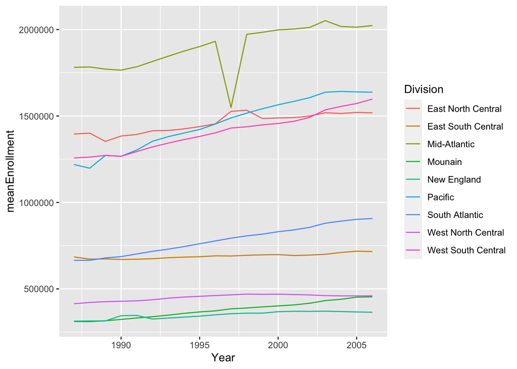

```r
plot(final_combined$state, var_name = "values" )
```

Plot for county :

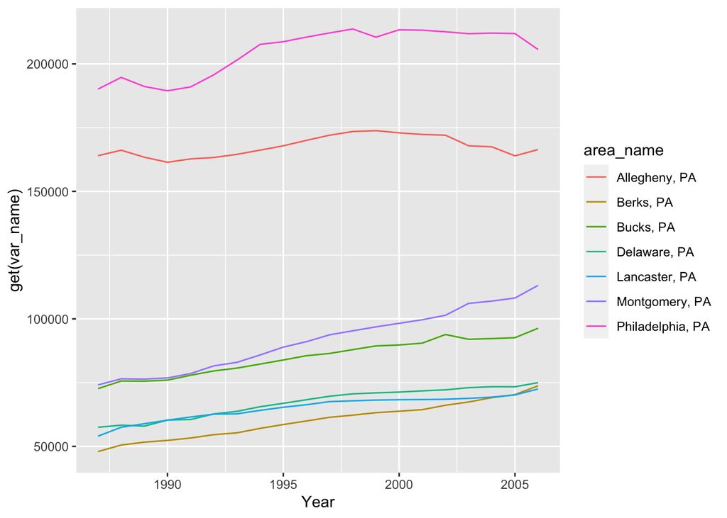

```r
plot(final_combined$county, var_name = "values", "PA", "top", 7)
```

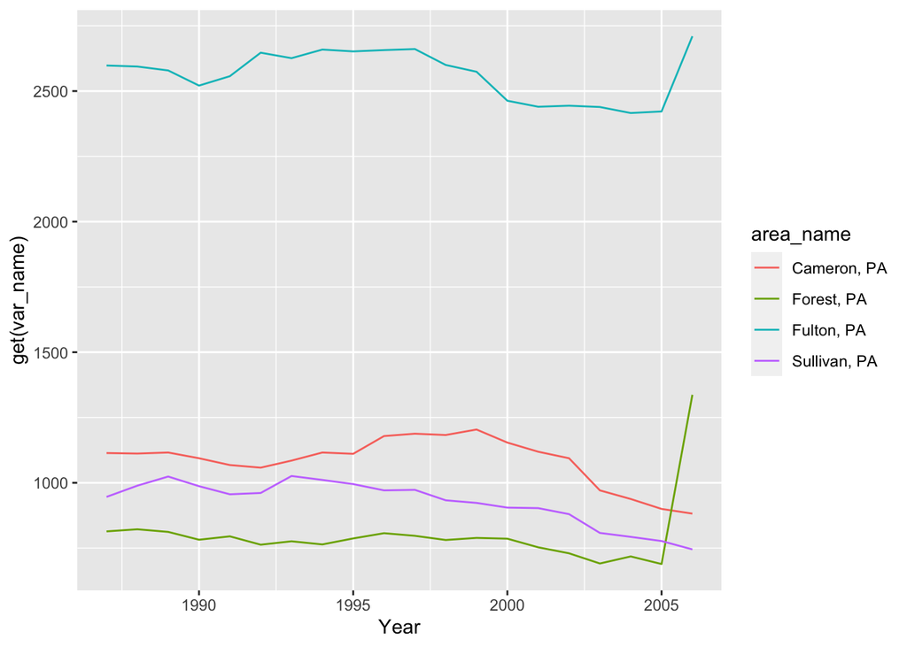

```r
plot(final_combined$county, var_name = "values", "PA", "bottom", 4)
```

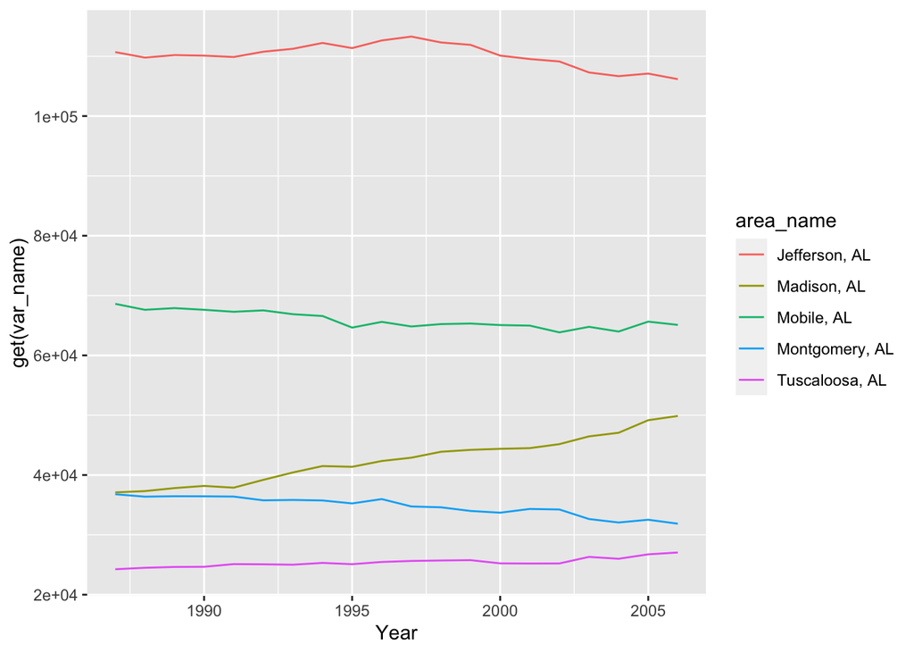

```r
plot(final_combined$county, var_name = "values")
```

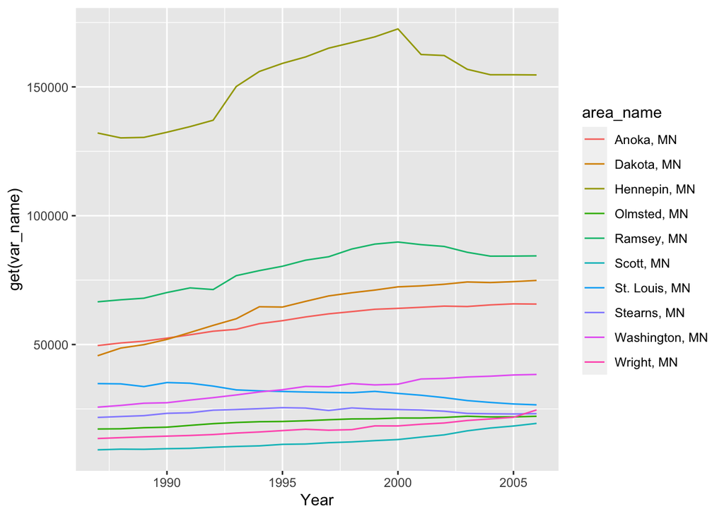

```r
plot(final_combined$county, var_name = "values", "MN", "top", 10)
```

Last part :

```r
dataset1 <- my_wrapper("https://www4.stat.ncsu.edu/~online/datasets/PST01a.csv")
dataset2 <- my_wrapper("https://www4.stat.ncsu.edu/~online/datasets/PST01b.csv")
dataset3 <- my_wrapper("https://www4.stat.ncsu.edu/~online/datasets/PST01c.csv")
dataset4 <- my_wrapper("https://www4.stat.ncsu.edu/~online/datasets/PST01d.csv")

comb1 <- combined_outputs(dataset1,dataset2)
comb2 <- combined_outputs(dataset3,dataset4)
comb3 <- combined_outputs(comb1,comb2)

comb3
```

```
## $county
## # A tibble: 125,800 × 7
##    area_name   STCOU Char       values Measurement  Year state
##    <chr>       <chr> <chr>       <dbl> <chr>       <dbl> <chr>
##  1 Autauga, AL 01001 PST015171D  25508 PST0151      1971 AL
##  2 Autauga, AL 01001 PST015172D  27166 PST0151      1972 AL
##  3 Autauga, AL 01001 PST015173D  28463 PST0151      1973 AL
##  4 Autauga, AL 01001 PST015174D  29266 PST0151      1974 AL
##  5 Autauga, AL 01001 PST015175D  29718 PST0151      1975 AL
##  6 Autauga, AL 01001 PST015176D  29896 PST0151      1976 AL
##  7 Autauga, AL 01001 PST015177D  30462 PST0151      1977 AL
##  8 Autauga, AL 01001 PST015178D  30882 PST0151      1978 AL
##  9 Autauga, AL 01001 PST015179D  32055 PST0151      1979 AL
## 10 Autauga, AL 01001 PST025181D  31985 PST0251      1981 AL
## # … with 125,790 more rows
##
## $state
## # A tibble: 2,120 × 7
##    area_name   STCOU Char        values Measurement  Year Division
##    <chr>       <chr> <chr>        <dbl> <chr>       <dbl> <chr>
##  1 CONNECTICUT 09000 PST015171D 3061448 PST0151      1971 New England
##  2 CONNECTICUT 09000 PST015172D 3069617 PST0151      1972 New England
##  3 CONNECTICUT 09000 PST015173D 3069140 PST0151      1973 New England
##  4 CONNECTICUT 09000 PST015174D 3075784 PST0151      1974 New England
##  5 CONNECTICUT 09000 PST015175D 3084726 PST0151      1975 New England
##  6 CONNECTICUT 09000 PST015176D 3085984 PST0151      1976 New England
##  7 CONNECTICUT 09000 PST015177D 3088729 PST0151      1977 New England
##  8 CONNECTICUT 09000 PST015178D 3094839 PST0151      1978 New England
##  9 CONNECTICUT 09000 PST015179D 3099907 PST0151      1979 New England
## 10 CONNECTICUT 09000 PST025181D 3128849 PST0251      1981 New England
## # … with 2,110 more rows
```

Plot on state

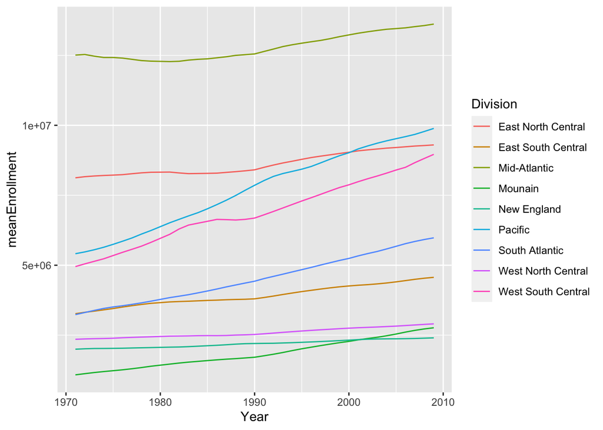

```r
plot(comb3$state, var_name = "values" )
```

Plots on county :

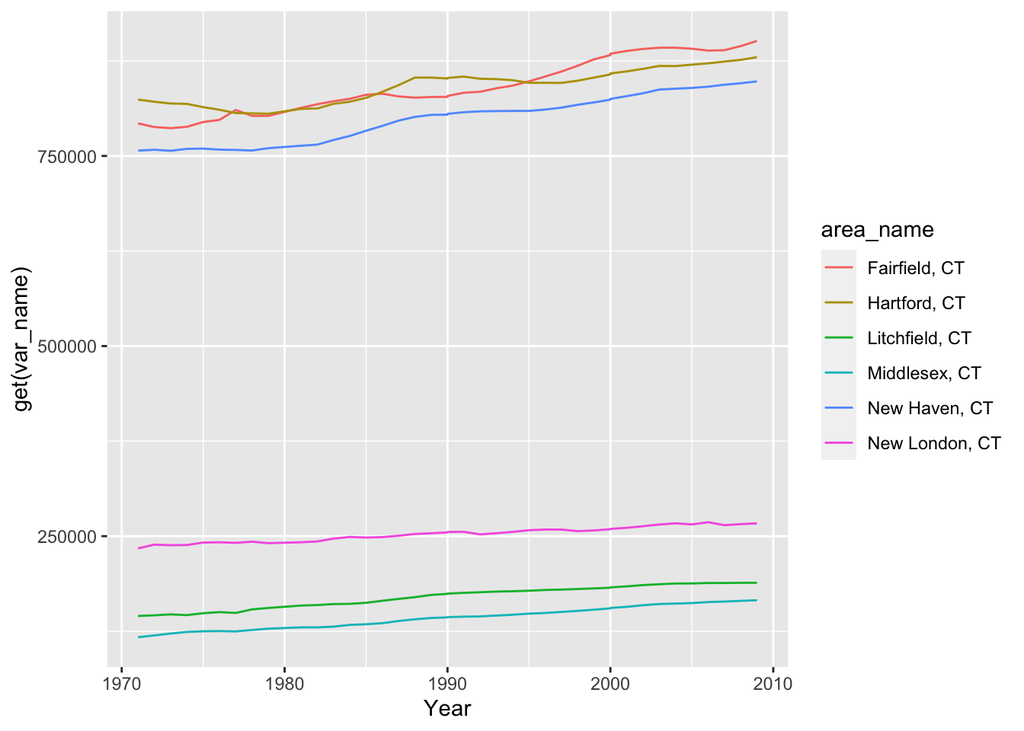

```r
plot(comb3$county, var_name = "values", "CT", "top", 6)
```

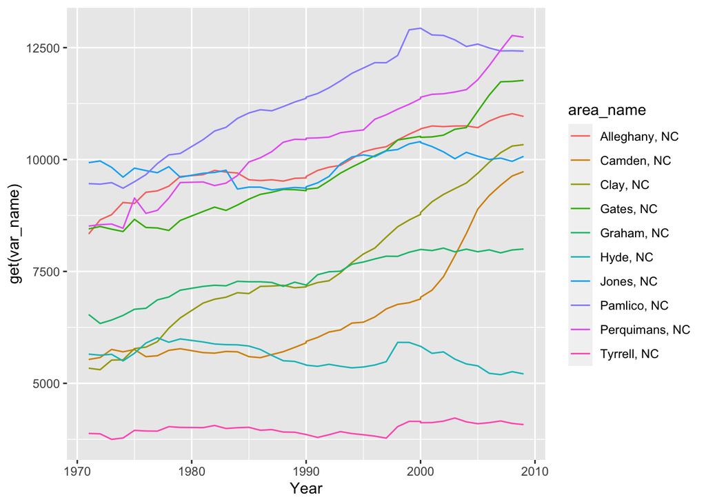

```r
plot(comb3$county, var_name = "values", "NC", "bottom", 10)
```

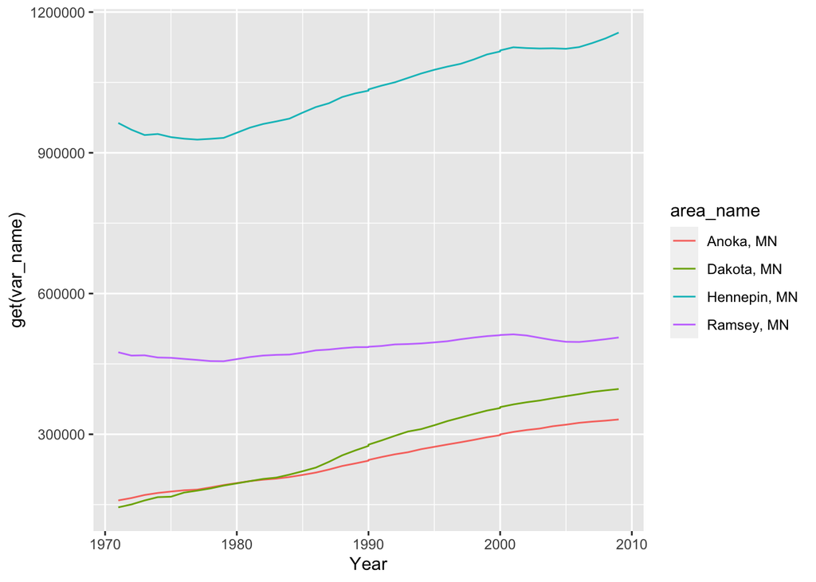

```r
plot(comb3$county, var_name = "values", "MN", "top", 4)
```

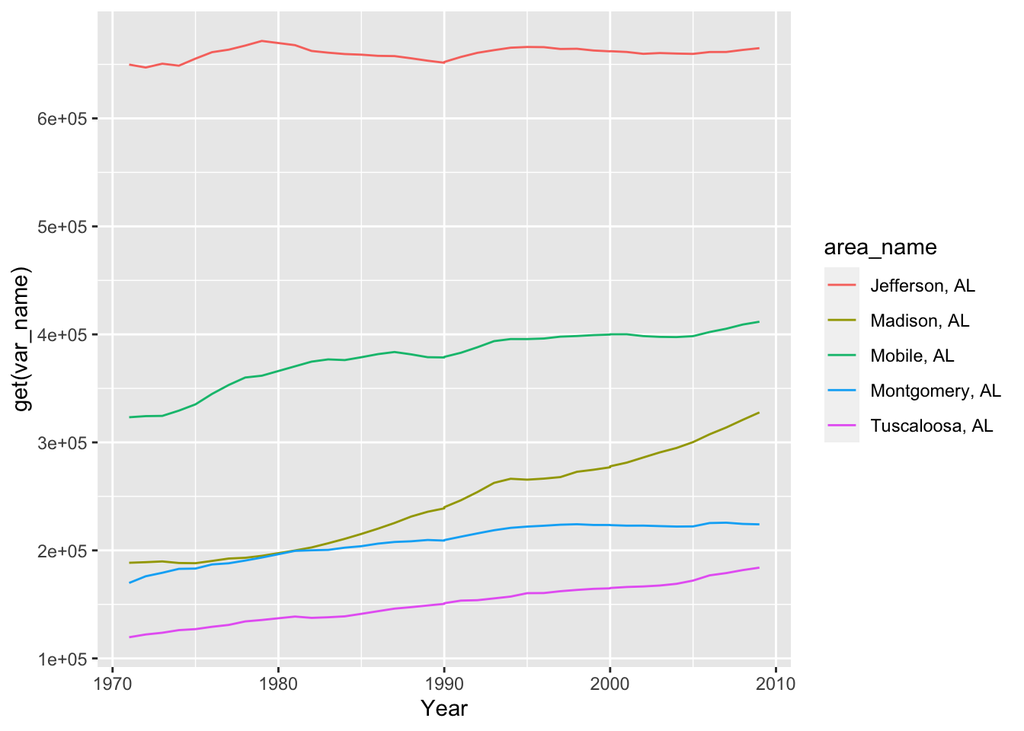

```r
plot(comb3$county, var_name = "values")
```